# Final Assignment - A Research Project on UK Police’s Stop and Search

2023-12-13

## I. Introduction

My research question is about if there are biases in who experiences stop and search by the UK Police, and I approached this question mainly by evaluating the gender, ethnicity, and age distribution among those who experienced stop and search. I also observed the ratio of whether outcome was linked to the initial reason for conducting the search. Finally, I analyzed the geographical differences and time trends for stop and search in the UK to understand potential biases from spatial and temporal factors. Link to my public Github repo to this project: https://github.com/ShirlyXue666/stop_and_search.git.

## II. Data

I utilized multiple data sources. First, I used the monthly stop and search data from UK police for the most recent year (Oct. 2022 to Oct. 2023) to analyze the gender, ethnicity, and age factors cross-sectionally. To obtain the total number of populations for different gender, ethnicity, and age, I also referenced and obtained relevant data from the UK Office for National Statistics. I then divided the stop and search count by those features by the number of UK population by these features to obtain the Ratio parameter. I also utilized the information on whether an outcome is linked to object of search and created the Link Ratio parameter to reflect the proportion of stop and search with linked outcome. After the cross-sectional analysis by gender, ethnicity, and age, I obtained the KML files from UK Police Data to draw the map and then web scraped the population by county data from the “Counties in England by population” Wikipedia page to obtain the stop and search count by county over county population data. I also plotted a time series of stop and search along with unemployment rate data from the UK Office for National Statistics.

## III. Analysis

### 0. Type of Search

```
## # A tibble: 3 × 4
##   Type                       Count  Link Link_by_Count
##   <chr>                      <int> <int>         <dbl>
## 1 Person and Vehicle search  62941 11225         0.178
## 2 Person search             348164 60776         0.175
## 3 Vehicle search             14745  1778         0.121
```

I summarized the “type of search” factor and found Person search the most frequent type, followed by Person and Vehicle search and then Vehicle search, which reflects that different human characteristics likely play a big role in who experiences stop and search.

### 1. Gender Analysis

```
## # A tibble: 4 × 5
##   Gender  Count  Link Link_Ratio    Ratio
##   <chr>   <int> <int>      <dbl>    <dbl>
## 1 Female  46479  8932      0.477  0.00153
## 2 Male   356162 60826      0.475  0.0122
## 3 Other    1834   383      0.234 NA
## 4 <NA>    21375  3638      0.482 NA
```

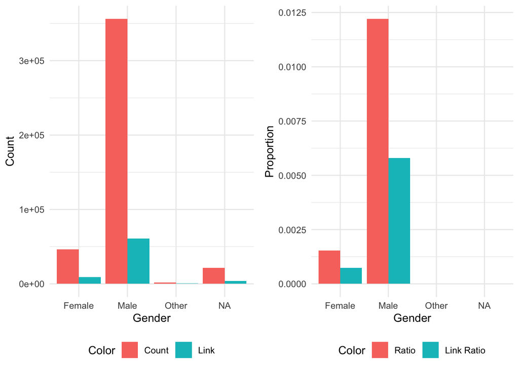

The graph above shows that males are more likely to experience stop and search than women, and that men experienced 7 times more than women by count and 8 times more by proportion.

### 2. Ethnicity

#### 2.1 Self-defined Ethnicity

```
##                                                                               Ethnicity
## 1                                      Asian/Asian British - Any other Asian background
## 2                                                     Asian/Asian British - Bangladeshi
## 3                                                         Asian/Asian British - Chinese
## 4                                                          Asian/Asian British - Indian
## 5                                                       Asian/Asian British - Pakistani
## 6                                       Black/African/Caribbean/Black British - African
## 7  Black/African/Caribbean/Black British - Any other Black/African/Caribbean background
## 8                                     Black/African/Caribbean/Black British - Caribbean
## 9             Mixed/Multiple ethnic groups - Any other Mixed/Multiple ethnic background
## 10                                       Mixed/Multiple ethnic groups - White and Asian
## 11                               Mixed/Multiple ethnic groups - White and Black African
## 12                             Mixed/Multiple ethnic groups - White and Black Caribbean
## 13                                          Other ethnic group - Any other ethnic group
## 14                                                            Other ethnic group - Arab
```

[output cut: 45 more lines]

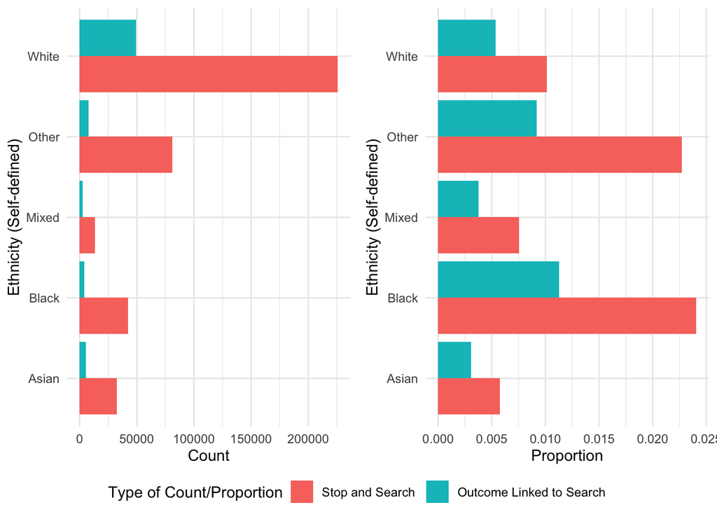

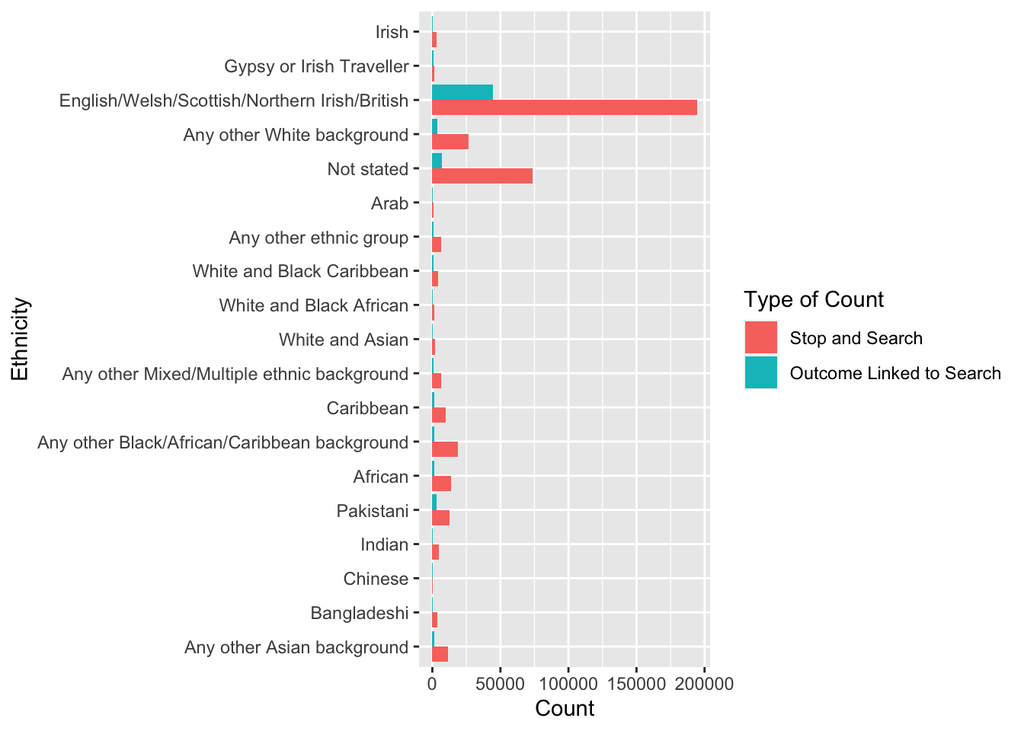

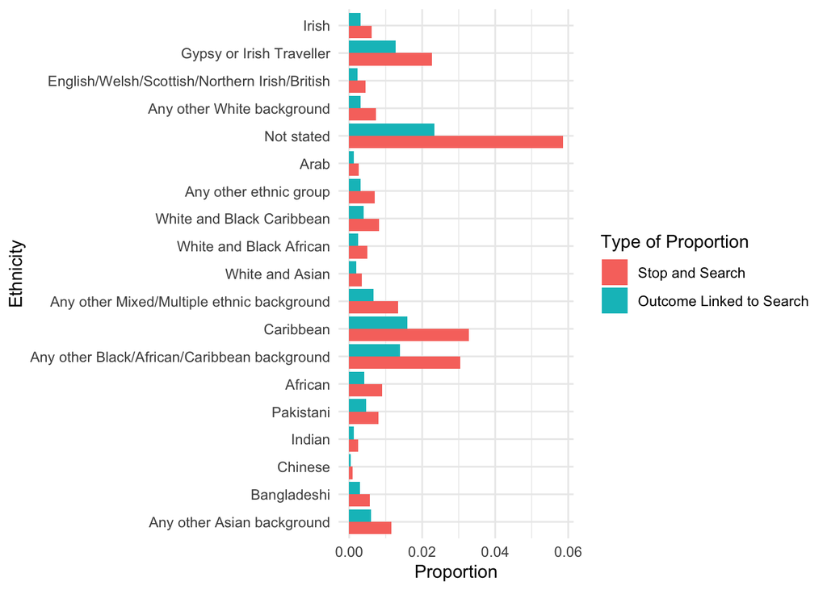

#### 2.2 Officer-defined Ethnicity

```
##   Ethnicity Percentage in Total Population Total Population
## 1     Asian                              9          5515455
## 2     Black                              4          2409283
## 3     Mixed                              3          1717977
## 4     Other                              4          2511264
## 5     White                             82         48598267
##   Stop and Search Count Link Count Population Ratio Link Proportion
## 1                 44521       6921     0.0080720448    0.0041666634
## 2                 69490       6320     0.0288426059    0.0125281972
## 3                   709        322     0.0004126947    0.0002657754
## 4                 13235       1902     0.0052702543    0.0022162334
## 5                264153      54082     0.0054354407    0.0026633039
```

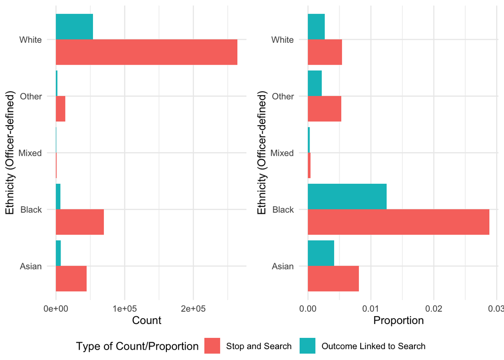

For ethnicity analysis, I conducted the analysis for both self-defined and officer-defined ethnicity. For the major 5 ethnic categories (after grouping by the specific categories for a more general understanding first), I found that for raw counts, White dominates as this is the dominant ethnic group (82% of total UK Population); however, when looking at proportions, I observed that Black, especially Black Caribbean, dominates, and the link ratio for White (0.4899886) is also higher than for Black (0.4343643), which implies that stop and search may be biased against Black and Mixed people (as no link means that the search is not linked, or related, to the outcome of the search). This trend persists for officer-defined ethnicity.

### 3. Age

```
##        Age Stop and search proportion Proportion of search linked to outcome
## 1    10-17                0.526704487                           0.2273341985
## 2    18-24                0.861000675                           0.4579078265
## 3    25-34                0.397282533                           0.2020389687
## 4  over 34                0.165876977                           0.0798060595
## 5 under 10                0.002112777                           0.0008837758
##   Stop and search count Count of search linked to outcome
## 1                 76596                             12434
## 2                108499                             22697
## 3                 85817                             17066
## 4                 98375                             17452
## 5                   370                                64
```

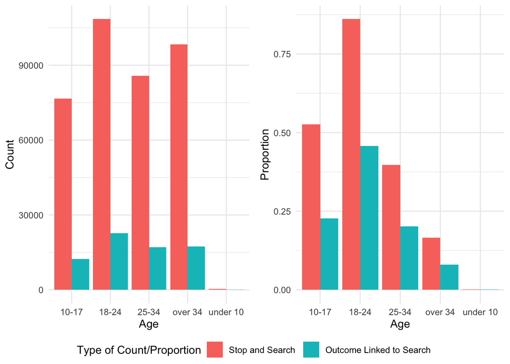

For raw counts of age analysis, all age groups have similar level of stop and search (except those under 10), but for proportions, 18-24 stands out with almost two times more than the neighboring age groups (10-17 and 25-34). The proportion of linked outcome for teenagers between 10-17 (0.4316162) is much lower than that for young adults between 18-24 (0.5318321) and adults between 24-34 (0.5085524), which reflects there may be bias against teenagers.

### 4. Map of geographical distribution

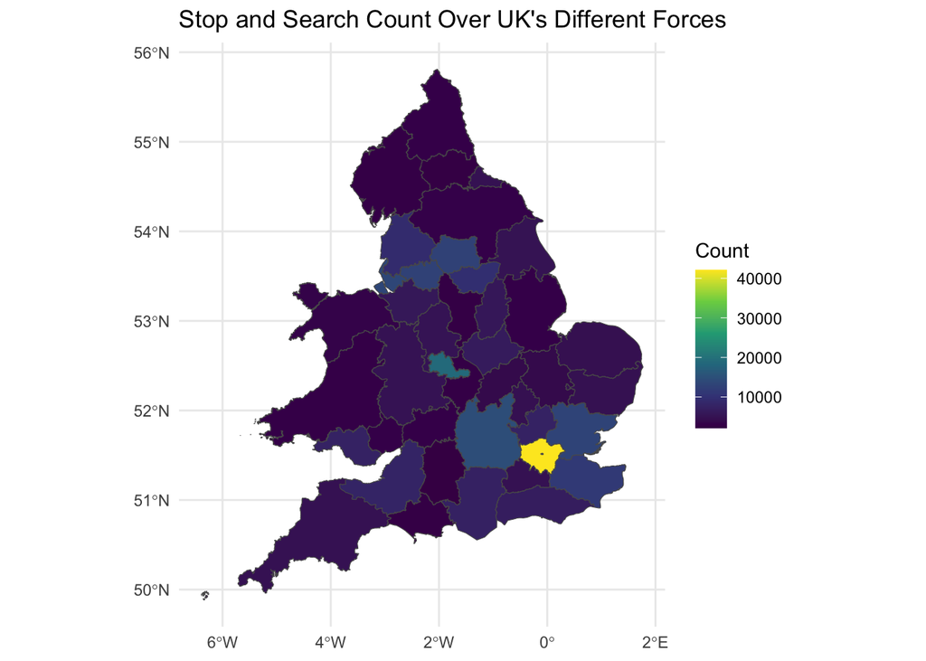

From this graph of raw counts, we can see that London has extremely more stop and search counts than other counties, followed by West Midlands, and then Thames Valley, Essex, Manchester, Merseyside, and West Yorks.

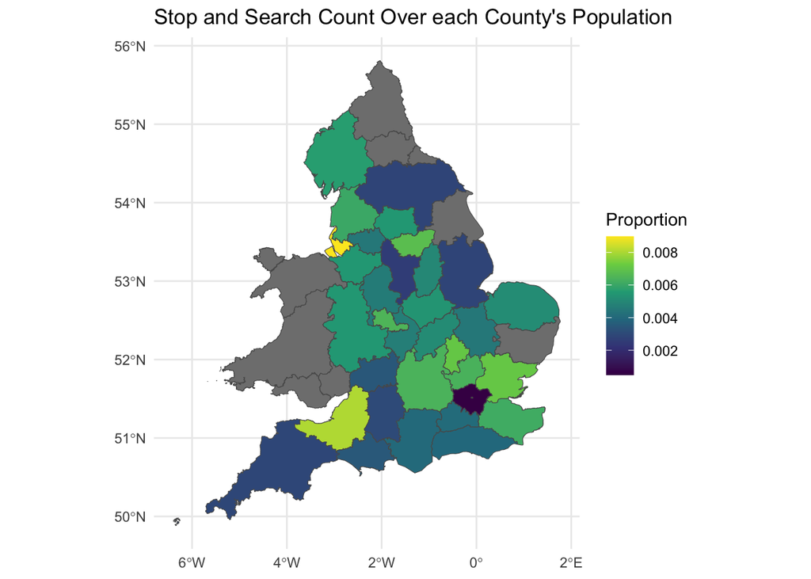

When looking at proportions, London (Metropolitan) has much less stop and search than other counties, while Merseyside has the highest proportion of 0.0089739305, followed by Avon & Somerset of 0.0080661241.

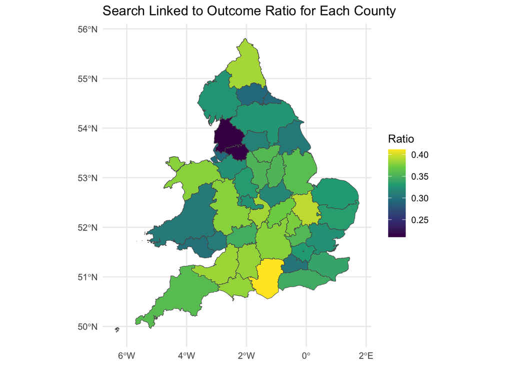

We can observe that Lancashire and Greater Manchester are where stop and search are much less linked to outcome, which may reflect that there might be more bias in who experience stop and search in these areas.

### 5. Time trend analysis

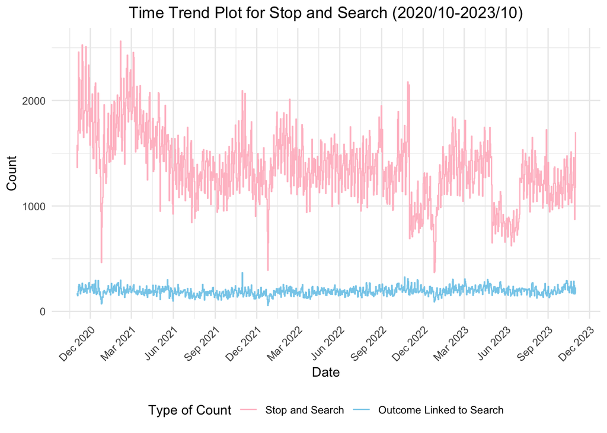

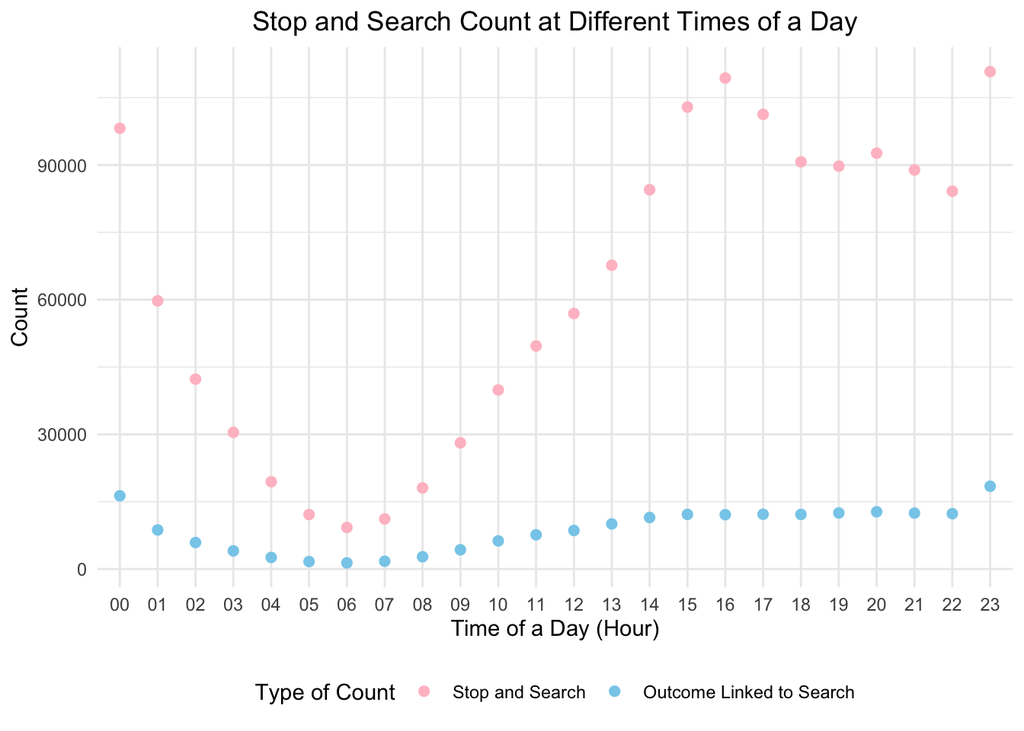

I also analyzed the frequency of stop and search at different times in a day and observed that nighttime being the most frequent time. This reflects that season and time may also be factors affecting bias in stop and search.

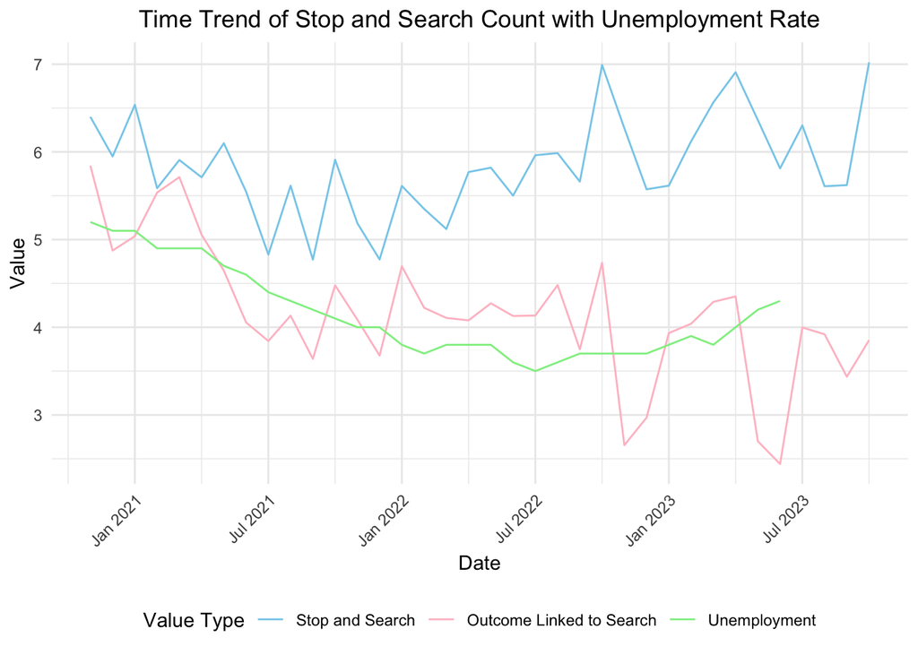

In conclusion, although further analysis controlling for season, time, economic conditions, and geographies may be conducted, I observed that people who are male, Black, and teenagers may be biased to experience more stop and search by the police.

## IV. Appendix: All code in this assignment

```r
knitr::opts_chunk$set(echo = FALSE)
options(message = FALSE)
options(warning = FALSE)
library(dplyr,quietly = TRUE) # Import relevant libraries.
library(readr,quietly = TRUE)
library(ggplot2, quietly = TRUE) # Import the ggplot2 library.
library(tidyverse,quietly = TRUE)
library(ggpubr)
library(reshape2)
years <- c("2022-11", "2022-12", "2023-01", "2023-02", "2023-03", "2023-04", "2023-05", "2023-06", "2023-07", "2023-08", "2023-09", "2023-10") # Specify the years of data that will be included for analysis.
all_data <- data.frame() # Create an empty data frame to store imported data.
for (i in years){ # Iterate through each year.
  df_i <- # Define a data frame for each year's data.
  suppressMessages(list.files(path = paste0("one_year_all_forces/", i),
                 pattern = "*.csv", full.names = TRUE) %>%
       lapply(read_csv) %>%
       bind_rows)
  all_data <- bind_rows(all_data, df_i) # Combine all the individual data frames from each year.
}
all_data_vehicle1 <- all_data %>% rename("outcome"= "Outcome linked to object of search") # Group the stop and search data by gender and rename the column a Gender.
all_data_vehicle <- all_data_vehicle1 %>% group_by(Type) %>% summarise(Count = n(), Link = sum(outcome == TRUE, na.rm = TRUE), Link_by_Count = Link/Count)
print(all_data_vehicle) # Show the type of search distribution table.
all_data_gender1 <- all_data %>% rename("outcome"= "Outcome linked to object of search") # Group the stop and search data by gender and rename the column a Gender.
all_data_gender <- all_data_gender1 %>% group_by(Gender) %>% summarise(Count = n(), Link = sum(outcome == TRUE, na.rm = TRUE), Link_Ratio = mean(outcome == TRUE, na.rm = TRUE)) %>% mutate(Ratio = c((46479/30420100), (356162/29177200), NA, NA)) # Obtain the total population by gender statistics and calculate the gender distribution.
print(all_data_gender) # Show the gender distribution table.

# Count plot
all_data_gender_c <- all_data_gender %>% select(c("Gender", "Count", "Link"))
all_data_gender_c_w <- melt(all_data_gender_c, id='Gender')
plot_gender_c_w <- ggplot(
  data = all_data_gender_c_w,
  mapping = aes(x = Gender, y = value, fill = variable) # View the plot by gender.
  ) + geom_bar(stat = "identity", position = "dodge") +
  labs(x = "Gender", y = "Count", fill = "Color") +
  theme_minimal()

# Proportion plot
all_data_gender_p <- all_data_gender %>% select(c("Gender", "Ratio", "Link_Ratio"))
all_data_gender_p <- all_data_gender_p %>% mutate(link_ratio = all_data_gender_p$Link_Ratio * all_data_gender_p$Ratio) %>% select(-Link_Ratio) %>% rename("Link Ratio" = "link_ratio") # Create a Ratio column.
all_data_gender_p_w <- melt(all_data_gender_p, id='Gender')

# Create a bar plot for gender distribution
plot_gender_p_w <- ggplot(
  data = all_data_gender_p_w,
  mapping = aes(x = Gender, y = value, fill = variable) # View the plot by gender.
  ) + geom_bar(stat = "identity", position = "dodge") +
  labs(x = "Gender", y = "Proportion", fill = "Color") +
  theme_minimal()

# Put the two General plots in one frame
combined_plot_gender <- ggarrange(plot_gender_c_w, plot_gender_p_w, common.legend = FALSE, legend = "bottom", ncol = 2)
combined_plot_gender
ppl_by_ethnicity <- read.csv("by-ethnicity-table.csv") # Obtain another data of total population by ethnicity from UK government statistics website.
all_data_ethnicity <- all_data %>% rename("Ethnicity" = "Self-defined ethnicity", "outcome"= "Outcome linked to object of search")
all_data_ethnicity <- all_data_ethnicity %>% group_by(Ethnicity) %>% summarise(Count = n(),Link = sum(outcome == TRUE, na.rm = TRUE), Link_ratio = mean(outcome == TRUE, na.rm = TRUE)) # Group the stop and search data by ethnicity.

merged_tot_ppl <- merge(ppl_by_ethnicity, all_data_ethnicity, by = "Ethnicity") # Merge the two tables.
merged_tot_ppl$Total_Population <- as.numeric(gsub(",", "", merged_tot_ppl$Total_Population)) # Remove the comma in total population column and make it numeric.
merged_tot_ppl$Ratio <- merged_tot_ppl$Count / merged_tot_ppl$Total_Population # Create a column of a stop and search ratio by ethnicity.
merged_tot_ppl$link_ratio <- merged_tot_ppl$Link_ratio * merged_tot_ppl$Ratio
merged_tot_ppl_present <- merged_tot_ppl %>% select(-c(Link_ratio)) %>% rename("Percentage in Total Population" = "perct_total_ppl", "Total Population" = "Total_Population", "Stop and Search Count" = "Count", "Link Count" = "Link", "Link Proportion" = "link_ratio", "Population Ratio" = "Ratio")
print(merged_tot_ppl_present) # Show the ethnicity distribution and statistics table.

merged_tot_ppl <- mutate(merged_tot_ppl, Umbrella = str_sub(merged_tot_ppl$Ethnicity, start = 1, end = 5)) # Create a new column classifying each ethnic group into their umbrella group
merged_tot_ppl_um <- merged_tot_ppl %>% group_by(Umbrella) %>% summarise(Sum_count = sum(Count), Sum_link = sum(Link), mean_Ratio = mean(Ratio), mean_Link_ratio = mean(link_ratio))

# General - count plot
merged_tot_ppl_um_count <- select(merged_tot_ppl_um, c("Umbrella", "Sum_count", "Sum_link")) %>% rename("Stop and Search" = "Sum_count", "Outcome Linked to Search" = "Sum_link")
merged_tot_ppl_um_count_wide <- melt(merged_tot_ppl_um_count, id='Umbrella') # Reframe the data for visualization.

plot_ethnicity_general_cnt <- ggplot() + # Create a bar plot for ethnicity distribution.
  geom_bar(data = merged_tot_ppl_um_count_wide,
  mapping = aes(x = value, y = Umbrella, fill = variable), stat = "identity", position = "dodge") +
  labs(x = "Count", y = "Ethnicity (Self-defined)", fill = "Type of Count/Proportion") + # Add labels.
  theme_minimal()

# General - ratio plot
merged_tot_ppl_um_ratio <- select(merged_tot_ppl_um, c("Umbrella", "mean_Ratio", "mean_Link_ratio")) %>% rename("Stop and Search" = "mean_Ratio", "Outcome Linked to Search" = "mean_Link_ratio")
merged_tot_ppl_um_ratio_wide <- melt(merged_tot_ppl_um_ratio, id='Umbrella')

plot_ethnicity_general_prop <- ggplot() + # Create a bar plot for ethnicity distribution.
  geom_bar(data = merged_tot_ppl_um_ratio_wide,
  mapping = aes(x = value, y = Umbrella, fill = variable), stat = "identity", position = "dodge") +
  labs(x = "Proportion", y = "Ethnicity (Self-defined)", fill = "Type of Proportion/Proportion") +
  theme_minimal()
# Put the two General plots in one frame
combined_general_plot <- ggarrange(plot_ethnicity_general_cnt, plot_ethnicity_general_prop, common.legend = TRUE, legend = "bottom", ncol = 2) # Make the two plots into one frame for easier comparisons.
combined_general_plot
```

```r
# Make plot of the stop and search distribution for specific ethnicity (Count)
merged_tot_ppl_faceted <- merged_tot_ppl %>% mutate(name = gsub(".*- ", "", merged_tot_ppl$Ethnicity)) %>% select(-c( perct_total_ppl, Total_Population, Link_ratio)) # Clean the ethnicity name column.
merged_tot_ppl_faceted_cnt <- merged_tot_ppl_faceted %>% select(Umbrella, name, Count, Link) %>% rename("Stop and Search" = "Count", "Outcome Linked to Search" = "Link") # Select the columns that will be used and rename the variables to more interpretable ones.
merged_tot_ppl_faceted_cnt_w <- melt(merged_tot_ppl_faceted_cnt, id=c('name', 'Umbrella')) # Reframe the table to make it ready for bar plotting of two variables for each feature/category.

plot_tot_ppl_faceted_cnt_w <- ggplot() + # Create a bar plot for ethnicity distribution.
  geom_bar(data = merged_tot_ppl_faceted_cnt_w,
  mapping = aes(x = value, y = factor(name, levels = unique(name)), fill = variable), stat = "identity", position = "dodge") +
  labs(x = "Count", y = "Ethnicity", fill = "Type of Count")
  #facet_wrap(vars(Umbrella)) +
  theme_minimal()
plot_tot_ppl_faceted_cnt_w

# Make plot of the stop and search distribution for specific ethnicity (Proportion)
merged_tot_ppl_faceted_prop <- merged_tot_ppl_faceted %>% select(Umbrella, name, Ratio, link_ratio) %>% rename("Stop and Search" = "Ratio", "Outcome Linked to Search" = "link_ratio")
merged_tot_ppl_faceted_prop_w <- melt(merged_tot_ppl_faceted_prop, id=c('name', 'Umbrella'))

plot_ethnicity_prop_f <- ggplot(data = merged_tot_ppl_faceted_prop_w, mapping = aes(x = value, y = factor(name, levels = unique(name)), fill = variable)) + # Create a bar plot for ethnicity distribution.
  geom_bar(stat = "identity", position = "dodge") +
  labs(x = "Proportion", y = "Ethnicity", fill = "Type of Proportion") +
  #facet_wrap(vars(Umbrella)) +
  theme_minimal()

merged_tot_ppl_present
combined_general_plot
plot_tot_ppl_faceted_cnt_w
plot_ethnicity_prop_f
ppl_by_ethnicity_O <- read.csv("by-ethnicity-table_Officer.csv") # Obtain another data of total population by ethnicity from UK government statistics website.
all_data_ethnicity_o <- all_data %>% rename("Ethnicity" = "Officer-defined ethnicity", "outcome"= "Outcome linked to object of search")
all_data_ethnicity_o <- all_data_ethnicity_o %>% group_by(Ethnicity) %>% summarise(Count = n(),Link = sum(outcome == TRUE, na.rm = TRUE), Link_ratio = mean(outcome == TRUE, na.rm = TRUE)) # Group the stop and search data by ethnicity.
merged_tot_ppl_o <- merge(ppl_by_ethnicity_O, all_data_ethnicity_o, by = "Ethnicity") # Merge the two tables.
merged_tot_ppl_o$Total_Population <- as.numeric(gsub(",", "", merged_tot_ppl_o$Total_Population)) # Remove the comma in total population column and make it numeric.
merged_tot_ppl_o$Ratio <- merged_tot_ppl_o$Count / merged_tot_ppl_o$Total_Population # Create a column of a stop and search ratio by ethnicity.
merged_tot_ppl_o$link_ratio <- merged_tot_ppl_o$Link_ratio * merged_tot_ppl_o$Ratio
merged_tot_ppl_present_o <- merged_tot_ppl_o %>% select(-c(Link_ratio)) %>% rename("Percentage in Total Population" = "perct_total_ppl", "Total Population" = "Total_Population", "Stop and Search Count" = "Count", "Link Count" = "Link", "Link Proportion" = "link_ratio", "Population Ratio" = "Ratio")
print(merged_tot_ppl_present_o) # Show the ethnicity distribution and statistics table.

# General - count plot
merged_tot_ppl_o_p <- select(merged_tot_ppl_o, c("Ethnicity","Count", "Link")) %>% rename("Stop and Search" = "Count", "Outcome Linked to Search" = "Link")
merged_tot_ppl_o_p_wide <- melt(merged_tot_ppl_o_p, id='Ethnicity')

plot_ethnicity_general_cnt_o <- ggplot() + # Create a bar plot for ethnicity distribution.
  geom_bar(data = merged_tot_ppl_o_p_wide,
  mapping = aes(x = value, y = Ethnicity, fill = variable), stat = "identity", position = "dodge") +
  labs(x = "Count", y = "Ethnicity (Officer-defined)", fill = "Type of Count/Proportion") +
  theme_minimal()

# General - ratio plot
merged_tot_ppl_o_ratio <- select(merged_tot_ppl_o, c("Ethnicity","Ratio", "link_ratio")) %>% rename("Stop and Search" = "Ratio", "Outcome Linked to Search" = "link_ratio")
merged_tot_ppl_o_ratio_wide <- melt(merged_tot_ppl_o_ratio, id='Ethnicity')

plot_ethnicity_general_prop_o <- ggplot() + # Create a bar plot for ethnicity distribution.
  geom_bar(data = merged_tot_ppl_o_ratio_wide,
  mapping = aes(x = value, y = Ethnicity, fill = variable), stat = "identity", position = "dodge") +
  labs(x = "Proportion", y = "Ethnicity (Officer-defined)", fill = "Type of Count/Proportion") +
  theme_minimal()

# Put the two General plots in one frame
combined_general_plot_O <- ggarrange(plot_ethnicity_general_cnt_o, plot_ethnicity_general_prop_o, common.legend = TRUE, legend = "bottom", ncol = 2) # Make the two plots into one frame for easier comparisons.
combined_general_plot_O
library(readxl, quietly=TRUE)
library(reshape2, quietly=TRUE)
all_data_age <- all_data %>% group_by(all_data$"Age range") %>% summarise(Count = n()) %>% rename("Age" = "all_data$\"Age range\"")

all_data_age1 <- all_data %>% rename("Age" = "Age range", "outcome"= "Outcome linked to object of search") %>% group_by(Age) %>% summarise(Count = n(), Link = sum(outcome == TRUE, na.rm = TRUE), Link_ratio = mean(outcome == TRUE, na.rm = TRUE))

age_ppl <- read_excel("edited_age_ppl.xlsx") # Read in the excel file (for replicating purpose, please change to your local directory to this file).
merged_age <- merge(all_data_age1, age_ppl, by = "Age")
merged_age$Ratio <- merged_age$Count/merged_age$Total_ppl_count
merged_age_count_link <- select(merged_age, "Age", "Count", "Link") %>% rename("Stop and Search" = "Count", "Outcome Linked to Search" = "Link")
merged_age_count_link_wide <- melt(merged_age_count_link, id='Age')

# Create a bar plot showing distribution of age (Count).
plot_age <- ggplot(data = merged_age_count_link_wide, mapping = aes(x = Age, y = value, fill = variable)) + geom_bar(stat = "identity", position = "dodge") +
  labs(x = "Age", y = "Count", fill = "Type of Count/Proportion") +
  theme_minimal()
```

```r
# Create a bar plot showing distribution of age (Proportion).
merged_age_count_link2 <- select(merged_age, "Age", "Ratio", "Link_ratio")
merged_age_count_link2$link_ratio <- merged_age_count_link2$Link_ratio * merged_age_count_link2$Ratio
merged_age_count_link3 <- select(merged_age_count_link2, -Link_ratio) %>% rename("Stop and Search" = "Ratio", "Outcome Linked to Search" = "link_ratio")
merged_age_count_link_wide3 <- melt(merged_age_count_link3, id='Age')

plot_age3 <- ggplot()+
  geom_bar(merged_age_count_link_wide3, stat = "identity", mapping = aes(x = Age, y = value, fill = variable), position = "dodge") +
  labs(x = "Age", y = "Proportion", fill = "Type of Count/Proportion") +
  theme_minimal()

combined_age <- merge(merged_age_count_link3, merged_age_count_link, by = "Age") %>% rename ("Stop and search proportion" = "Stop and Search.x", "Proportion of search linked to outcome" = "Outcome Linked to Search.x", "Stop and search count" = "Stop and Search.y", "Count of search linked to outcome" = "Outcome Linked to Search.y")
print(combined_age) # Present the combined table.
combined_plot_age <- ggarrange(plot_age, plot_age3, common.legend = TRUE, legend = "bottom", ncol = 2) # Make the two plots into one frame for easier comparisons.
combined_plot_age
library(stringr) # Import relevant libraries.
library(sf)
library(leaflet)
ods <- read_csv("ods/stop-search-open-data-tables-mar21-mar23 (1).csv") # Import a combined data set from 2020 to 2023 (for replicating purpose, please change to your local directory to this file).

kml_files <- list.files(path = "force_kmls", full.names = TRUE) # Import KML files of each force (for replicating purpose, please change to your local directory to this file).

all_kml_data <- lapply(kml_files, st_read) %>%
  bind_rows() # Read all KML files and combine them into one sf object.

all_kml_data <- all_kml_data %>% mutate(file_name = tools::file_path_sans_ext(basename(kml_files))) # Create a new column showing the name of the force each kml file represents.

# Make the force names of all_kml_data same as that of ods.
all_kml_data$file_name1 <- str_replace_all(all_kml_data$file_name, "-and-", " & ")
all_kml_data$file_name1 <- str_replace_all(all_kml_data$file_name1, "-", " ")
all_kml_data$file_name1 <- gsub("\\b([a-z])", "\\U\\1", all_kml_data$file_name1, perl = TRUE)
all_kml_data$file_name1[5] <- "London, City of"
all_kml_data$file_name1[12] <- "Dyfed-Powys"
all_kml_data$file_name1[25] <- "Metropolitan Police"
all_kml_data <- all_kml_data %>% rename("police_force_area" = "file_name1")

merged_data1 <- merge(all_kml_data, ods, by = "police_force_area") # Merge the ods and all_kml_data data.
merged_data2 <- merged_data1 %>% group_by(merged_data1$geometry) %>% summarise(Count = n(), police_force_area = first(police_force_area)) # Group by the data by each force to visualize the geographical difference among difference forces.

# Plot the data to create a map showing counts of stop and search in different UK forces.
plot_geo_1 <- ggplot() +
  geom_sf(data = merged_data2, aes(fill = Count)) +
  theme_minimal() +
  scale_fill_viridis_c(option = "viridis") +
  labs(title = "Stop and Search Count Over UK's Different Forces", fill = "Count")
  #geom_text(data = merged_data2, aes(label = merged_data2$police_force_area), color = "black", size = 3, check_overlap = TRUE)

plot_geo_1
library(rvest)  # Load relevant libraries for webscraping population by UK county data.
url <- "https://en.wikipedia.org/wiki/Counties_in_England_by_population"
webpage <- read_html(url)
tables <- html_table(webpage, fill = TRUE)
ppl_by_county <- tables[[2]]
ppl_by_county <- ppl_by_county %>% select(-c(Rank, Region))
ppl_by_county$"Total population" <- as.numeric(gsub(",", "", ppl_by_county$"Total population")) # Remove the comma in total population column and make it numeric.
ppl_by_county$County[1] <- "London, City of" # Correct the names to make the tables able to merge by county names.
ppl_by_county$County[22] <- "Avon & Somerset"
ppl_by_county <- ppl_by_county[-c(30, 35), ]
ppl_by_county$County[23] <- "Thames Valley"
ppl_by_county$`Total population`[23]<- sum(ppl_by_county$`Total population`[23], ppl_by_county$`Total population`[30],ppl_by_county$`Total population`[35])
ppl_by_county <- ppl_by_county[-c(30, 35), ]
ppl_by_county$County[12] <- "Devon & Cornwall"
ppl_by_county$`Total population`[12]<- sum(ppl_by_county$`Total population`[12], ppl_by_county$`Total population`[38])
ppl_by_county <- ppl_by_county[-38, ]
ppl_by_county$`Total population`[21]<- sum(ppl_by_county$`Total population`[21], ppl_by_county$`Total population`[41]) # Adding Rutland to Leicestershire.
ppl_by_county <- ppl_by_county[-41, ]
ppl_by_county$County[41] <- "West Mercia" # Summing Herefordshire, Worcestershire, Shropshire to West Mercia
ppl_by_county$`Total population`[41]<- sum(ppl_by_county$`Total population`[41], ppl_by_county$`Total population`[36], ppl_by_county$`Total population`[39])
ppl_by_county <- ppl_by_county[-c(36, 39), ]
ppl_by_county$`Total population`[22]<- sum(ppl_by_county$`Total population`[22], ppl_by_county$`Total  population`[38]) # Adding Bristol to Avon & Somerset.
ppl_by_county <- ppl_by_county[-38, ]
ppl_by_county$`Total population`[5]<- sum(ppl_by_county$`Total population`[5], ppl_by_county$`Total  population`[40]) # Adding Isle of Wight to Hampshire.
ppl_by_county <- ppl_by_county[-40, ]
ppl_by_county$County[27] <- "Sussex" # Summing East Sussex and West Sussex to Sussex
ppl_by_county$`Total population`[27]<- sum(ppl_by_county$`Total population`[27], ppl_by_county$`Total population`[29])
ppl_by_county <- ppl_by_county[-29, ]
merged_data3 <- merged_data2

merged_data3 <- merged_data3 %>% rename("County" = "police_force_area")
merged_county <- left_join(merged_data3, ppl_by_county, by = "County")
merged_county$Count_prop <- merged_county$Count/ merged_county$`Total population`
merged_county$Count_prop[25] <- merged_county$Count_prop[23]
county_prop_plot <-ggplot() +
  geom_sf(data = merged_county, aes(fill = Count_prop)) +
  theme_minimal() +
  scale_fill_viridis_c(option = "viridis") +
  labs(title = "Stop and Search Count Over each County's Population", fill = "Proportion")
county_prop_plot
merged_data4 <- merged_data1 %>% group_by(merged_data1$geometry) %>% summarise(Link = mean(link == "Linked"), police_force_area = first(police_force_area))
```

```r
county_link_prop_plot <-ggplot() +
  geom_sf(data = merged_data4, aes(fill = Link)) +
  theme_minimal() +
  scale_fill_viridis_c(option = "viridis") +
  labs(title = "Search Linked to Outcome Ratio for Each County", fill = "Ratio")
county_link_prop_plot
two_years <- c("2020-11", "2020-12", "2021-01", "2021-02", "2021-03", "2021-04", "2021-05", "2021-06", "2021-07", "2021-08", "2021-09", "2021-10", "2021-11", "2021-12", "2022-01", "2022-02", "2022-03", "2022-04", "2022-05", "2022-06", "2022-07", "2022-08", "2022-09", "2022-10") # Specify the years of data that will be included for analysis.
all_data_twoyrs <- data.frame() # Create an empty data frame to store imported data.
for (i in two_years){ # Iterate through each year.
  df_i <- # Define a data frame for each year's data.
  suppressMessages(list.files(path = paste0("other_two_years/", i), # For replicating purpose, please change to your local directory to this file.
                 pattern = "*.csv", full.names = TRUE) %>%
       lapply(read_csv) %>%
       bind_rows)
  all_data_twoyrs <- bind_rows(all_data_twoyrs, df_i) # Combine all the individual data frames from each year.
}

all_years <- bind_rows(all_data_twoyrs, all_data) # Combine the three years' data.
all_data_time <- all_years %>% rename("outcome"= "Outcome linked to object of search")
all_data_time <- all_data_time %>% group_by(Date)%>% summarise(Count = n(), Link = sum(outcome == TRUE, na.rm = TRUE))

datetime_posix <- as.POSIXct(all_data_time$Date, format = "%Y-%m-%d %H:%M:%S")

# Extract date and time components
date_component <- format(datetime_posix, "%Y-%m-%d")
time_component <- format(datetime_posix, "%H:%M:%S")
hour_part <- substr(time_component, 1, 2)
all_data_time <- all_data_time %>% mutate(date_component, time_component,hour_part)
all_data_time_by_day <- all_data_time %>% group_by(date_component) %>% summarise(Count = sum(Count), Link = sum(Link))
all_data_time_by_time <- all_data_time %>% group_by(hour_part) %>% summarise(Count = sum(Count), Link = sum(Link))

# Plot long-term time trend distribution (2020-2023)
all_data_year_long <- pivot_longer(all_data_time_by_day, cols = c(Count, Link), names_to = "Variable", values_to = "Value") # Reform the data.
all_data_year_long$date_component <- as.Date(all_data_year_long$date_component)

year_trend_plot <- ggplot(all_data_year_long, aes(x = date_component, y = Value, color = Variable)) +
  geom_step(size = 0.5) +
  labs(title = "Time Trend Plot for Stop and Search (2020/10-2023/10)",
       x = "Date",
       y = "Count",
       color = "Variable") +
  theme_minimal() +
  scale_color_manual(values = c("Count" = "pink", "Link" = "skyblue"),
                     name = "Type of Count",
                     labels = c("Stop and Search", "Outcome Linked to Search"))+
  scale_x_date(date_breaks = "3 month", date_labels = "%b %Y") +
  theme(axis.text.x = element_text(angle = 45, hjust = 1), legend.position = "bottom", legend.box = "horizontal", plot.title = element_text(hjust = 0.5))

# Plot time of a day distribution
all_data_time_long <- pivot_longer(all_data_time_by_time, cols = c(Count, Link), names_to = "Variable", values_to = "Value") # Reform the data.

time_plot <- ggplot(all_data_time_long, aes(x = hour_part, y = Value, color = Variable)) +
  geom_point(size = 2) +
  labs(title = "Stop and Search Count at Different Times of a Day",
       x = "Time of a Day (Hour)",
       y = "Count",
       color = "Variable") +
  theme_minimal() +
  scale_color_manual(values = c("Count" = "pink", "Link" = "skyblue"),
                     name = "Type of Count",
                     labels = c("Stop and Search", "Outcome Linked to Search")) +
  theme(legend.position = "bottom", legend.box = "horizontal", plot.title = element_text(hjust = 0.5))
suppressWarnings({
  year_trend_plot
})
  time_plot
library(zoo)
# Import unemployment rate data
Umdata <- read.csv("unemp_rate.csv")
date_object <- as.Date(paste(Umdata$Date, "01"), format = "%Y %b %d")
Umdata$Date <- date_object
Umdata$Date <- sub("-\\d+$", "", Umdata$Date)
Umdata$Date <- as.yearmon(Umdata$Date, format = "%Y-%m")
Umdata <- Umdata %>% rename("unemployment" = "percent")

# Proportion data for count
all_data_time_by_day1 <- all_data_time_by_day
yr_month <- sub("-\\d+$", "", all_data_time_by_day1$date_component)
all_data_time_by_day1$Date <- yr_month
all_data_time_by_day1 <- select(all_data_time_by_day1, -date_component)
all_data_time_by_day1 <- all_data_time_by_day1 %>% group_by(Date) %>% summarise(month_sum = sum(Count), link_sum = sum(Link))
all_data_time_by_day1$month_sum <- all_data_time_by_day1$month_sum/ 10000 # Dividing by 10000 to adjust its scale for better visible comparison with unemployment rate data.
all_data_time_by_day1$link_sum <- all_data_time_by_day1$link_sum/ 1000 # Same as above - adjust scale for visualization purpose.
all_data_time_by_day1$Date <- as.yearmon(all_data_time_by_day1$Date, format = "%Y-%m")
merged_um <- left_join(all_data_time_by_day1, Umdata,by = join_by(Date))
merged_um_long <- pivot_longer(merged_um, cols = c(month_sum, link_sum, unemployment), names_to = "Variable", values_to = "Value") # Reshape the data.
merged_um_long$Date <- as.yearmon(merged_um_long$Date, format = "%Y-%m")

year_trend_plot_um <- ggplot() + # Plotting the combined data.
  geom_line(merged_um_long, mapping = aes(x = Date, y = Value, color = Variable), size = 0.5) +
  labs(title = "Time Trend of Stop and Search Count with Unemployment Rate",
       x = "Date",
       y = "Value") +
  theme_minimal() +
  scale_color_manual(values = c("month_sum" = "pink", "link_sum" = "skyblue", "unemployment" = "lightgreen"),
                     name = "Value Type",
                     labels = c("Stop and Search", "Outcome Linked to Search", "Unemployment"))+
  #scale_x_date(date_breaks = "6 month", date_labels = "%b %Y") +
  theme(axis.text.x = element_text(angle = 45, hjust = 1), legend.position = "bottom", legend.box = "horizontal", plot.title = element_text(hjust = 0.5))
suppressWarnings({
  year_trend_plot_um
})
# this chunk generates the complete code appendix.
# eval=FALSE tells R not to run (``evaluate'') the code here (it was already run before).
```